# 4 Logistic Regression 2

Author

Lin Yu

Published

February 10, 2025

```r
library(dplyr)
library(ggplot2)
library(DT)
library(here)
```

## 4.1 Recap of Tutorial 3

1. How would you calculate the estimated mean outcome (probability of otucome being positive, $E(Y) = P(Y=1)$)

**Check Answer**

$\hat P(Y=1) = \frac{exp(\hat Z)}{1+exp(\hat Z)}$, where $Z$ is the linear combination of predictors

2. For (generalized) linear regression $g(E(Y)) = \beta_0 + \beta_1 X_1 +\ldots + \beta_p X_p$, the MLE estimators $\boldsymbol{\hat \beta} = [ \hat\beta_0, \hat \beta_1,\ldots \hat \beta_p]$ follows a multivariate normal distribution, each $\hat \beta$ is a normal distribution.
3. if I have a R.V. $\hat \beta = [\hat \beta_1, \hat \beta_2]$ follows a bivariate normal distribution, how do we calculate the variance for $\beta_1+\beta_2$ , and for $a \beta_1 + b\beta_2$?

**Check Answer**

$$\begin{bmatrix} \beta_1 \\ \beta_2 \end{bmatrix} \sim N\left( \begin{bmatrix} \mu_1 \\ \mu_2 \end{bmatrix}, \begin{bmatrix} \sigma_1^2 & \rho \sigma_1 \sigma_2 \\ \rho \sigma_1 \sigma_2 & \sigma_2^2 \end{bmatrix} \right),$$

where $\rho \sigma_1 \sigma_2$ is the covariance between $\beta_1$ and $\beta_2$.

the variance of $\beta_1 + \beta_2$ is given by:
$$\text{Var}(\beta_1 + \beta_2) = \sigma_1^2 + \sigma_2^2 + 2\rho \sigma_1 \sigma_2.$$
$$\text{Var}(a\beta_1 + b\beta_2) = a^2\sigma_1^2 + b^2\sigma_2^2 + 2ab\rho \sigma_1 \sigma_2.$$

4. Given 1-3, do you know how can we calculate the variance of the estiamted probability of the outcome being positive ($\hat P(Y=1)$)?

```r
library(rms)
load(here("data","tutdata.RData"))
dd <- datadist(tutdata)
options(datadist = "dd")

fit1 <- glm(y ~ blood.pressure + sex + age + cholesterol, data = tutdata,family = binomial("logit"))

summary(fit1)
```

```
Call:
glm(formula = y ~ blood.pressure + sex + age + cholesterol, family = binomial("logit"),
    data = tutdata)

Coefficients:
                Estimate Std. Error z value Pr(>|z|)
(Intercept)    -1.777923   0.822041  -2.163 0.030555 *
blood.pressure -0.002645   0.004299  -0.615 0.538367
sexmale         0.474873   0.129886   3.656 0.000256 ***
age             0.033198   0.006587   5.040 4.66e-07 ***
cholesterol     0.001845   0.002652   0.696 0.486489
---
Signif. codes:  0 '***' 0.001 '**' 0.01 '*' 0.05 '.' 0.1 ' ' 1

(Dispersion parameter for binomial family taken to be 1)

    Null deviance: 1379.9  on 999  degrees of freedom
Residual deviance: 1339.6  on 995  degrees of freedom
AIC: 1349.6

Number of Fisher Scoring iterations: 4
```

```r
anova(fit1)
```

```
Analysis of Deviance Table

Model: binomial, link: logit

Response: y

Terms added sequentially (first to last)

               Df Deviance Resid. Df Resid. Dev
NULL                             999     1379.9
blood.pressure  1   0.2057       998     1379.7
sex             1  13.0804       997     1366.6
age             1  26.5172       996     1340.1
cholesterol     1   0.4846       995     1339.6
```

```r
fit1 %>% coef()
```

```
   (Intercept) blood.pressure        sexmale            age    cholesterol
  -1.777923213   -0.002645049    0.474872640    0.033197626    0.001845301
```

```r
fit1 %>% vcov()
```

```
                (Intercept) blood.pressure       sexmale           age
(Intercept)     0.675751422  -2.230627e-03 -8.100279e-03 -2.126477e-03
blood.pressure -0.002230627   1.848061e-05 -4.786796e-06 -1.078910e-06
sexmale        -0.008100279  -4.786796e-06  1.687037e-02  3.554780e-05
age            -0.002126477  -1.078910e-06  3.554780e-05  4.338693e-05
cholesterol    -0.001467499   3.526787e-07 -4.926132e-06  3.650156e-07
                 cholesterol
(Intercept)    -1.467499e-03
blood.pressure  3.526787e-07
sexmale        -4.926132e-06
age             3.650156e-07
cholesterol     7.031300e-06
```

```r
## point estimate of beta_sex
beta_sex_hat <- coef(fit1)["sexmale"]

## standard error for coef of sex
beta_sex_se <- sqrt(vcov(fit1)[3,3])

## we know beta_hat follows a normal distribution, with mean=beta_sex_hat,

alpha <- qnorm(0.975,mean=0,sd=1)
alpha
```

```
[1] 1.959964
```

```r
upper <- exp(beta_sex_hat + alpha*beta_sex_se)
lower <- exp(beta_sex_hat - alpha*beta_sex_se)

lower
```

```
 sexmale
1.246452
```

```r
upper
```

```
 sexmale
2.073928
```

```r
predict(fit1,type="response") %>% head()
```

```
        1         2         3         4         5         6
0.5283084 0.5846051 0.4750915 0.5317948 0.6572165 0.6022435
```

```r
design_matrix <- model.matrix(y~blood.pressure + sex + age + cholesterol, data=tutdata)

design_matrix %>% head()
```

```
  (Intercept) blood.pressure sexmale      age cholesterol
1           1       98.37248       1 39.84991    191.6668
2           1      112.99815       1 49.20363    168.1024
3           1      100.90785       0 47.67013    196.4870
4           1      122.22211       1 41.82732    197.8634
5           1      125.38972       1 57.72091    200.2004
6           1      118.71428       1 48.34388    231.3853
```

```r
design_matrix[1,]
```

```
   (Intercept) blood.pressure        sexmale            age    cholesterol
       1.00000       98.37248        1.00000       39.84991      191.66681
```

```r
fit1 %>% coef()
```

```
   (Intercept) blood.pressure        sexmale            age    cholesterol
  -1.777923213   -0.002645049    0.474872640    0.033197626    0.001845301
```

```r
## linear combination of predictors
Z <- design_matrix[1,] %*% (fit1 %>% coef())

p_hat <- exp(Z)/(1+exp(Z))

p_hat
```

```
          [,1]
[1,] 0.5283084
```

## 4.2 Tutorial 4

```r
fit1 <- lrm(y ~ blood.pressure + sex + age + rcs(cholesterol,4), data = tutdata)
```

```r
fit2 <- lrm(y ~ blood.pressure + sex * (age + rcs(cholesterol,4)), data = tutdata)
anova(fit2)
```

```
                Wald Statistics          Response: y

 Factor                                           Chi-Square d.f. P
 blood.pressure                                    0.26       1   0.6105
 sex  (Factor+Higher Order Factors)               38.71       5   <.0001
  All Interactions                                26.13       4   <.0001
 age  (Factor+Higher Order Factors)               30.42       2   <.0001
  All Interactions                                 3.86       1   0.0495
 cholesterol  (Factor+Higher Order Factors)       23.78       6   0.0006
  All Interactions                                22.47       3   0.0001
  Nonlinear (Factor+Higher Order Factors)          5.33       4   0.2550
 sex * age  (Factor+Higher Order Factors)          3.86       1   0.0495
 sex * cholesterol  (Factor+Higher Order Factors) 22.47       3   0.0001
  Nonlinear                                        4.79       2   0.0911
  Nonlinear Interaction : f(A,B) vs. AB            4.79       2   0.0911
 TOTAL NONLINEAR                                   5.33       4   0.2550
 TOTAL INTERACTION                                26.13       4   <.0001
 TOTAL NONLINEAR + INTERACTION                    26.81       6   0.0002
 TOTAL                                            62.26      10   <.0001
```

```r
anova(fit2)
```

```
                Wald Statistics          Response: y

 Factor                                           Chi-Square d.f. P
 blood.pressure                                    0.26       1   0.6105
 sex  (Factor+Higher Order Factors)               38.71       5   <.0001
  All Interactions                                26.13       4   <.0001
 age  (Factor+Higher Order Factors)               30.42       2   <.0001
  All Interactions                                 3.86       1   0.0495
 cholesterol  (Factor+Higher Order Factors)       23.78       6   0.0006
  All Interactions                                22.47       3   0.0001
  Nonlinear (Factor+Higher Order Factors)          5.33       4   0.2550
 sex * age  (Factor+Higher Order Factors)          3.86       1   0.0495
 sex * cholesterol  (Factor+Higher Order Factors) 22.47       3   0.0001
  Nonlinear                                        4.79       2   0.0911
  Nonlinear Interaction : f(A,B) vs. AB            4.79       2   0.0911
 TOTAL NONLINEAR                                   5.33       4   0.2550
 TOTAL INTERACTION                                26.13       4   <.0001
 TOTAL NONLINEAR + INTERACTION                    26.81       6   0.0002
 TOTAL                                            62.26      10   <.0001
```

compare two models using LRT. To use LRT, one model needs to be nested within a larger model.

```r
lrtest(fit1,fit2)
```

```
Model 1: y ~ blood.pressure + sex + age + rcs(cholesterol, 4)
Model 2: y ~ blood.pressure + sex * (age + rcs(cholesterol, 4))

  L.R. Chisq         d.f.            P
2.831616e+01 4.000000e+00 1.076137e-05
```

visualize the effect modifications:

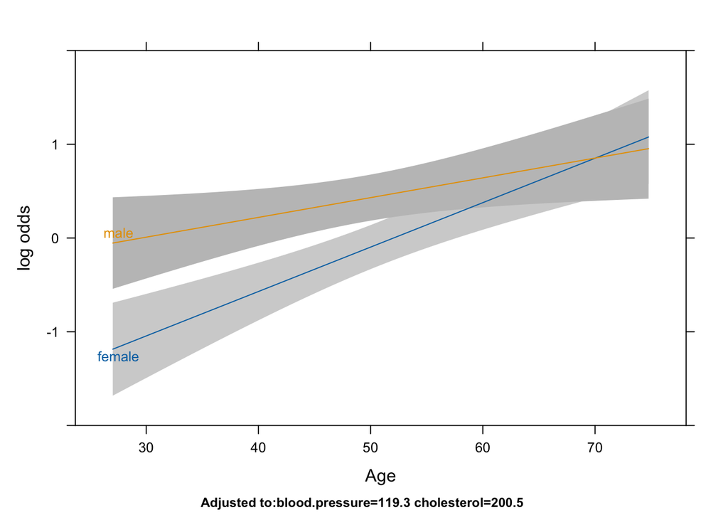

```r
plot(Predict(fit2,age,sex))
```

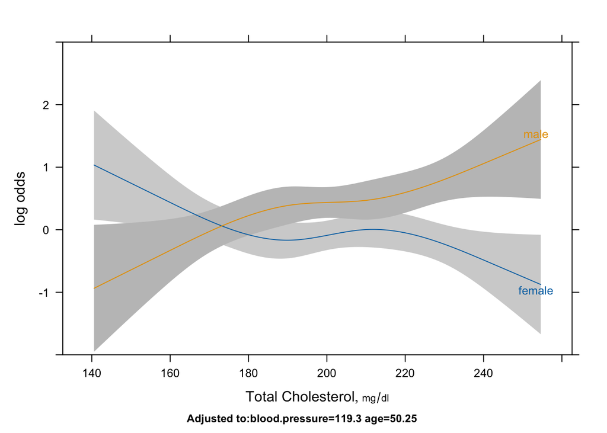

```r
plot(Predict(fit2,cholesterol,sex))
```

what would the plots look like without effect modification:

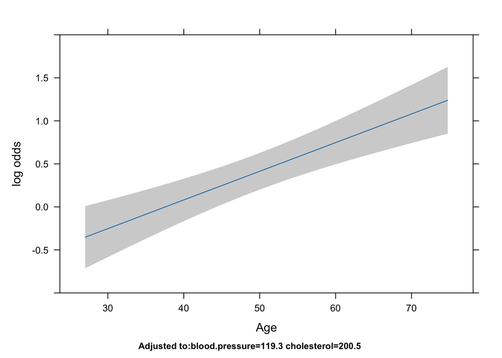

```r
plot(Predict(fit1, age, sex = "male"))
```

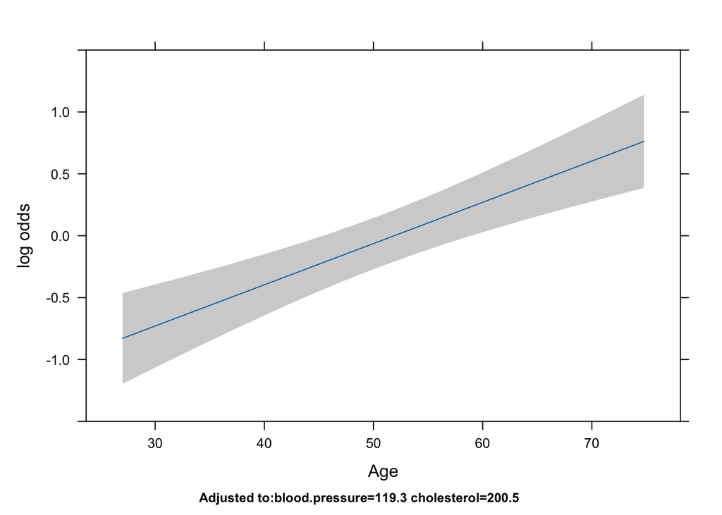

```r
plot(Predict(fit1, age, sex = "female"))
```